# Lecture 2

Latent Gaussian Models and INLA

Sara Martino

sara.martino@ntnu.no

Dept. of Mathematical Science, NTNU

## Main elements of the INLA methodology

- Latent Gaussian Models
- Sparse matrices
- Laplace approximations
- …other “technical” details for the special interested!

# Latent Gaussian Models (repetition)

## Repetition

Everything in INLA is based on so-called **latent Gaussian models**

- A few hyperparameters $\theta\sim\pi(\theta)$ control variances, range and so on
- Given these hyperparameters we have an underlying Gaussian distribution $\mathbf{u}|\theta\sim\mathcal{N}(\mathbf{0},\mathbf{Q}^{-1}(\theta))$ that we cannot directly observe
- Instead we make indirect observations $\mathbf{y}|\mathbf{u},\theta\sim\pi(\mathbf{y}|\mathbf{u},\theta)$ of the underlying latent Gaussian field

## Repetition

Models of this kind:
$$\begin{aligned}
\mathbf{y}|\mathbf{x},\theta &\sim \prod_i \pi(y_i|\eta_i,\theta)\\
\mathbf{\eta} & = A_1\mathbf{u}_1 + A_2\mathbf{u}_2+\dots + A_k\mathbf{u}_k\\
\mathbf{u},\theta &\sim \mathcal{N}(0,\mathbf{Q}(θ)^{−1})\\
\theta & \sim \pi(\theta)
\end{aligned}$$

occurs in many, seemingly unrelated, statistical models.

## Examples

- Generalised linear (mixed) models
- Stochastic volatility
- Generalised additive (mixed) models
- Measurement error models
- Spline smoothing
- Semiparametric regression
- Space-varying (semiparametric) regression models
- Disease mapping
- Log-Gaussian Cox-processes
- Model-based geostatistics (*)
- Spatio-temporal models
- Survival analysis
- +++

## Main Characteristics

1. Latent **Gaussian** model $\mathbf{u}|\theta\sim\mathcal{N}(0,\mathbf{Q}^{-1}(\theta))$
2. The data are *conditionally independent* given the latent field
3. The predictor is linear wrt the elements of $\mathbf{u}$<sup>1</sup>
4. The dimension of $\mathbf{u}$ can be big ($10^3-10^6$)
5. The dimension of $\theta$ should be not too big.

In this talk we will focus on the characteristics of $\mathbf{u}|\theta$

[^1]: we will see that this can be partly relaxed 😃

## The big n problem!

For many interesting applications it is necessary to solve large problems.

- With large problems we think of models where the size $n$ of the latent field $\mathbf{u}$ is between 100 to 100, 000. This includes fixed effects, spatial effects and so on.
- Computations with models of this size are cumbersome!
- The solution in the *INLA world* are **Gaussian Markov random fields (GMRFs)**!

# Gaussian Markov random fields

## The Gaussian distribution

A Gaussian distribution $\mathbf{u}\sim\mathcal{N}(0,\Sigma)$ is controlled by:

— The mean vector $\mu$, which we have set equal to 0. This is the centre of the distribution

— The matrix $\Sigma$ describes all pairwise covariances $\Sigma_{ij} = \text{Cov}(u_i, u_j)$

Formally
$$\pi(\mathbf{u}) = \frac{1}{2\pi|\Sigma|^{1/2}}\exp\left\{-\frac{1}{2}\mathbf{u}^T\Sigma^{-1}\mathbf{u}\right\}$$

## The Gaussian distribution

| Advantages 😄👍 | Disadvantages 😔👎 |
| --- | --- |
| **mostly theoretical** | **mostly computational** |
| Analytically tractable. | $Sigma$ usually is large and **dense** |
| We have a good understanding of its properties. | Computations scale as $\mathcal{O}(n^3)$ |
| Basically, it’s easy to do the theory | Not feasible for large problems |

We need to reduce the computational burden !

## Sparse matrices

> A matrix $\mathbf{Q}$ is called *sparse* if most of its elements is zero.

$$\mathbf{Q} = \begin{bmatrix}
1 & 0 & 0 & 0\\
0& 2& 0 & 0\\
0& 0& -1 & 0\\
0& 1& 0 & 0.4\\
\end{bmatrix}$$

— There exist very efficient numerical algorithms to deal with sparse matrices

— In order to solve large problems we need to exploit some property to make the computations feasible

Which matrix should be sparse in a Gaussian field?

## Two possible options

$$\mathcal{u}\sim\mathcal{N}(0,\Sigma)$$

1. Force the *covariance* matrix $\Sigma$ to be sparse
2. Force the *precision* matrix $\Sigma^{-1}$ to be sparse

## Two possible options

$$\mathcal{u}\sim\mathcal{N}(0,\Sigma)$$

1. Force the *covariance* matrix $\Sigma$ to be sparse
   - $\Sigma_{ij} = \text{Cov}(u_i, u_j)$ : Covariance between $u_i$ and $u_j$
   - $\Sigma_{ij} = 0$ $\longrightarrow$ $u_i$ and $u_j$ are *independent*
   - A sparse covariance matrix implies that many elements of $\mathbf{u}$ are mutually independent…..is this desirable?
2. Force the *precision* matrix $\mathbf{Q} = \Sigma^{-1}$ to be sparse

## Two possible options

$$\mathcal{u}\sim\mathcal{N}(0,\Sigma)$$

1. Force the *covariance* matrix $\Sigma$ to be sparse
   - $\Sigma_{ij} = \text{Cov}(u_i, u_j)$ : Covariance between $u_i$ and $u_j$
   - $\Sigma_{ij} = 0$ $\longrightarrow$ $u_i$ and $u_j$ are *independent*
   - A sparse covariance matrix implies that many elements of $\mathbf{u}$ are mutually independent…..is this desirable?
2. Force the *precision* matrix $\mathbf{Q} = \Sigma^{-1}$ to be sparse
- What does $Q_{ij}$ represents?
- What does a sparse precision matrix implies?

## Example: The AR1 proces

**Definition**

$$\begin{aligned}
\mathbf{i=1}&: u_1 \sim\mathcal{N}(0, \frac{1}{1-\phi^2})\\
\mathbf{i>1}&: u_i = \phi\ u_{i-1} +\epsilon_i,\ \epsilon_i\sim\mathcal{N}(0,1)
\end{aligned}$$

- Very common to model dependence in time
- The *joint* distribution of $u_1,u_2,\dots,u_N$ is Gaussian
- How do covariance and precision matrices look?

## Covariance and Precision Matrix for AR1

**Covariance Matrix**

$$\Sigma = \frac{1}{1-\phi^2} \begin{bmatrix}
1& \phi & \phi^2 & \dots& \phi^N \\
\phi & 1& \phi & \dots& \phi^{N-1} \\
\phi^2 & \phi & 1 & \dots& \phi^{N-2} \\
\dots& \dots& \dots& \dots& \dots& \\
\phi^{N} & \phi^{N-1}& \phi^{N-2} & \dots& 1\\
\end{bmatrix}$$
- This is a *dense* matrix.

- All elements of the $\mathbf{u}$ vector are *dependent*.

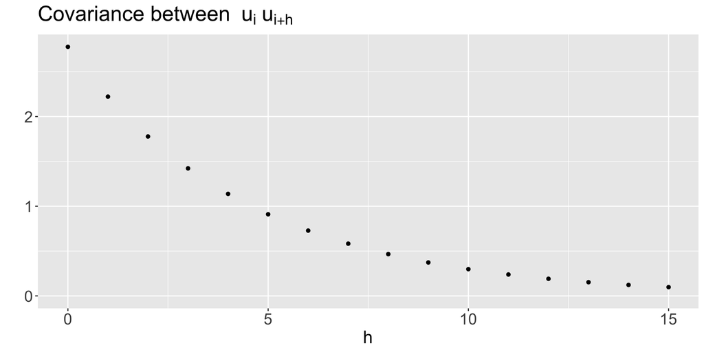

## Covariance and Precision Matrix for AR1

**Precision Matrix**

- The tridiagonal form of $\mathbf{Q}$ can be exploited for quick calculations.
- What is the key property of this example that causes $\mathbf{Q}$ to be sparse?

## Conditional independence

The key lies in the **full conditionals**

- Each timepoint is only **conditionally dependent** on the two closest timepoints
- It is useful to represent the conditional independence structure through a graph

[figure not shown]

## Conditional independence and the precision matrix

This is the key property! 😃

## (Informal) definition of a GMRF

— A **GMRF** is a Gaussian distribution where the non-zero elements of the precision matrix are defined by the graph structure.

— In the previous example the precision matrix is tridiagonal since each variable is connected only to its predecessor and successor.

## GMRF and INLA

- All models in INLA are GMRF
- We will see how the idea of GMRF expands also for continuously indexed processes (SPDE approach)

## What do we need to be able to compute?

- We need to compute determinants of large, sparse matrices. This is needed for likelihood calculations.
- We need to compute square roots of large, sparse matrices. This is needed for likelihood calculations and simulations.

**Technically:**

- In the end our computations come down to the Cholesky decomposition, $\mathbf{Q} = \mathbf{LL}^T$
- After $\mathbf{L}$ is available, things are fast
- The limiting factor is how quickly the Cholesky factorization can be done

## What is the gain?

- Temporal structure uses $\mathcal{O}(n)$ operations
- Spatial structure uses $\mathcal{O}(n^{3/2})$ operations
- Spatio-temporal structure uses $\mathcal{O}(n^{2})$ operations

Compare this with $\mathcal{O}(n^{3})$ operations in the general case.

## Summary

Gaussian Markov Random Fields (GMRF):

- Give faster computations, both in INLA and in MCMC schemes (thanks to sparse precision matrices)
- Keep the analytical tractability of the Gaussian distribution
- Allow modelling through conditional distributions
- Naturally arises from the SPDE approach (that we will talk about …..)

## Formal definition of a GMRF

> **Definition**

> A random variable $\mathbf{u}$ is said to be a Gaussian Markov random field (GMRF) with respect to the graph $\mathcal{G}$, with vertices $\{1, 2,\dots , n\}$ and edges $\mathcal{E}$, with mean $\mu$ and precision matrix $\mathbf{Q}$ if its probability distribution is given by
> $$\pi(\mathbf{u}) = \frac{|\mathbf{Q}|^{1/2}}{(2\pi)^{n/2}}\exp\left\{ -\frac{1}{2}(\mathbf{u}-\mu)^T\mathbf{Q}(\mathbf{u}-\mu)\right\}$$
> and $Q_{ij} \neq 0\Longleftrightarrow \{i,j\}\in\mathcal{E}$

# How INLA works

## Our model

## The INLA recipe

- Numerical integration schemes
- The GMRF-Approximation
- The Laplace approximation
- …many many many “technical” details

## Hierarchical GMRF

- $\mathbf{y}|\mathbf{x},\theta$, Observation model (likelihood)
- $\mathbf{x}|\theta$, Gaussian random field
- $\theta$ Hyperparameters

## Hierarchical GMRF

- $\mathbf{y}|\mathbf{x},\theta$, Observation model (likelihood)
- $\mathbf{x}|\theta$, Gaussian random field
- $\theta$ Hyperparameters

### Extra requirements

1. The latent field $\mathbf{x}$ is a GMRF
   $$\pi(\mathbf{x}|\theta)\propto\exp\left\{-\frac{1}{2}\mathbf{x}^T\mathbf{Q}\mathbf{x}\right\}$$
   - The precision matrix $\mathbf{Q}$ is sparse.

## Hierarchical GMRF

- $\mathbf{y}|\mathbf{x},\theta$, Observation model (likelihood)
- $\mathbf{x}|\theta$, Gaussian random field
- $\theta$ Hyperparameters

### Extra requirements

1. The latent field $x$ is a GMRF $\pi(\mathbf{x}|\theta)\propto\exp\left\{-\frac{1}{2}\mathbf{x}^T\mathbf{Q}\mathbf{x}\right\}$
2. We can factorize the likelihood as: $\pi(\mathbf{y}|\mathbf{x},\theta) = \prod_i\pi(y_i|\eta_i,\theta)$
   - Data are conditional independent give $\mathbf{x}$ and $\theta$
   - Each data point depends on only 1 element of the latent field: the *predictor* $\eta_i$
   - $\eta$ is a *linear* combination of other elements of $\mathbf{x}$: $\eta = \mathbf{A}^T\mathbf{x}$

## Hierarchical GMRF

- $\mathbf{y}|\mathbf{x},\theta$, Observation model (likelihood)
- $\mathbf{x}|\theta$, Gaussian random field
- $\theta$ Hyperparameters

### Extra requirements

1. The latent field $x$ is a GMRF $\pi(\mathbf{x}|\theta)\propto\exp\left\{-\frac{1}{2}\mathbf{x}^T\mathbf{Q}\mathbf{x}\right\}$
2. We can factorize the likelihood as: $\pi(\mathbf{y}|\mathbf{x},\theta) = \prod_i\pi(y_i|\eta_i,\theta)$
3. The vector of hyperparameters $\theta$ is low dimensional.

## Inference

**Main Inferential Goal**:

$$\begin{aligned}
\overbrace{\pi(\mathbf{x}, {\theta}\mid\mathbf{y})}^{{\text{Posterior}}} &\propto \overbrace{\pi({\theta}) \pi(\mathbf{x}\mid{\theta})}^{{\text{Prior}}} \overbrace{\prod_{i}\pi(y_i \mid \eta_i, {\theta})}^{{\text{Likelihood}}}
\end{aligned}$$

- The posterior distribution is, in general, not available in closed form…
- ..what to do then?
- 20 years ago MCMC was practically the only answer.

## Our inferential goal

[figure not shown]